# Decay of the ISS Orbit.

#### Plot eccentricity over time

```python
fig1, ax1 = plt.subplots(figsize=fs_default)
ax1.plot(dt2,eccmag2,c='grey')

slope, intercept, r_value, p_value, std_err = stats.linregress(dt2,eccmag2)
line = slope*dt2+intercept
ax1.plot(dt2,line,'r--',lw=1)

ax1.set_title('Eccentricity :  $\Delta e$/$\Delta t$={0:0.2e} yr$^-1$'.format(slope,intercept))
ax1.set_xlabel('Time (yr)')
ax1.set_ylabel('Eccentricity (km/km)')
ax1.legend(['e','linear regression'],loc='upper right')
plt.show()
print('Eccentricity decay over {0:0.2f} years'.format(dt2[-1] ))
print('Δe = {0:0.4f}'.format(eccmag2[-1] - eccmag2[0] ))
```

[figure not shown]

```
Eccentricity decay over 5.00 years
Δe = -0.0013
```

#### Plot Perigee and Apoapsis Values over Time

```python
fig3, ax3 = plt.subplots(figsize=fs_default)

c_rp = 'orange'
c_ra = 'purple'

#apoapsis
ax3.plot(dt2,r2_a - re,c=c_ra,lw=3,label='$apogee$')
slope, intercept, r_value, p_value, std_err = stats.linregress(dt2,r2_a - re)
line = slope*dt2+intercept
ax3.plot(dt2,line,'r--',lw=1,label='$\Delta r_a$/$\Delta t$ = {0:0.1f} km/yr'.format(slope))

#perigee
ax3.plot(dt2,r2_p  - re,c=c_rp,lw=3,label='$perigee$')
slope, intercept, r_value, p_value, std_err = stats.linregress(dt2,r2_p - re)
line = slope*dt2+intercept
ax3.plot(dt2,line,'b--',lw=1,label='$\Delta r_p$/$\Delta t$ = {0:0.1f} km/yr'.format(slope))


ax3.set_title('Atmospheric Drag: Perigee and Apoapsis Values')
ax3.set_ylabel('$Altitude$   (km)')
ax3.set_xlabel('Time  (years)')
ax3.legend(loc='center right')
ax3.grid(True)
plt.show()
```

[figure not shown]

#### Re-frame the Above Plot.

```python
# %% Plot flat orbit with r_a and r_p

r2_a_shift = r2_a-r2_a[0]
r2_p_shift = r2_p-r2_p[0]

fig4, ax4 = plt.subplots(figsize=fs_default)

#apoapsis
ax4.plot(dt2,r2_a_shift,c=c_ra,lw=3,label='$r_a$')
slope, intercept, r_value, p_value, std_err = stats.linregress(dt2,r2_a_shift)
line = slope*dt2+intercept
ax4.plot(dt2,line,'r--',lw=1,label='$\Delta r_a$/$\Delta t$ = {0:0.1f} km/yr'.format(slope))

#perigee
ax4.plot(dt2,r2_p_shift,c=c_rp,lw=3,label='$r_p$')
slope, intercept, r_value, p_value, std_err = stats.linregress(dt2,r2_p_shift)
line = slope*dt2+intercept
ax4.plot(dt2,line,'b--',lw=1,label='$\Delta r_p$/$\Delta t$ = {0:0.1f} km/yr'.format(slope))


ax4.set_title('Atmospheric Drag: Perigee and Apoapsis Values (arbitrary initial values)')
ax4.set_ylabel('$r$   (km)')
ax4.set_xlabel('Time  (years)')
ax4.legend(loc='lower left')
plt.show()
```

[figure not shown]

The above plot shows a relatively steady perigee. We know the drag force is largest at perigee due to increased atmospheric density, similar to an instantaneous ΔV maneuver at perigee, this location remains 'pinned'.

#### 'Manually' find r_a, r_p index locations.

```python
# %% 'Micro View': FIND r_a and r_p locations, and plot over r vs t.

r1_apo = find_peaks(r1_mag)
r1_peri = find_peaks(-r1_mag)

plt.figure(figsize=fs_default)

#Plot r
plt.plot(dt1_days,r1_mag,color='k')

#Plot the found r_a,t_p locations
for i in range(r1_peri[0].size - 1): #
    j = r1_peri[0][i]
    j1 = r1_apo[0][i]
    plt.scatter(dt1_days[j],r1_mag[j], c=c_ra)
    plt.scatter(dt1_days[j1],r1_mag[j1], c=c_rp)
plt.legend(['|r|','Apogee','Perigee'],loc=1)
plt.title('Test: Find Perigee and Apoasis Values Through Peak Searching')
plt.show()
```

[figure not shown]

#### Recalculate Deceleration and Velocity Values (were not saved from inside 2body loop)

```python
# RECALCULATE ACCEL (#Using r1, v1 ,dt1 )
# For the tail end of the high resolution data!!!
a1 = np.zeros((dt1.size,3))
for i in range(dt1.size):
    a1[i,:] = a_drag_fn(r1[i,:],r1_mag[i],v1[i,:])

a1_mag =  la.norm(a1,axis=1)
```

```python
# Recalculate V_rel
v1rel = np.zeros((dt1.size,3))
for i in range(dt1.size):
    v1rel[i,:] = v_rel_fn(r1[i,:],v1[i,:],omega_earth)

v1rel_mag = la.norm(v1rel,axis=1)
```

#### Trying to understand where the negative deceleration is coming from.

```python
dt1_yr = dt1 / Y2S
dt1_day = dt1 / D2S

fig5, ax5 = plt.subplots(3, figsize=(11,8), sharex=True)
ax5[0].plot(dt1_day, r1[:,0],c='r',label='$r_x$')
ax5[0].plot(dt1_day, r1[:,1],c='g', label='$r_y$')
ax5[0].plot(dt1_day, r1[:,2],c='b', label='$r_z$')
ax5[0].plot(dt1_day, r1_mag[:],c='k', label='|r|')

ax5[1].plot(dt1_day, v1rel[:,0],c='r', label='$v_x$')
ax5[1].plot(dt1_day, v1rel[:,1],c='g', label='$v_y$')
ax5[1].plot(dt1_day, v1rel[:,2],c='b', label='$v_z$')
ax5[1].plot(dt1_day, v1rel_mag,c='k', label='|v|')

ax5[2].plot(dt1_day, a1[:,0],c='r', label='$a_x$')
ax5[2].plot(dt1_day, a1[:,1],c='g', label='$a_y$')
ax5[2].plot(dt1_day, a1[:,2],c='b', label='$a_z$')
ax5[2].plot(dt1_day, a1_mag,c='k', label='|a|')

#r_a and r_p
for i in range(r1_apo[0].size): #
    j1 = r1_apo[0][i]
    if i ==0:
        ax5[0].scatter(dt1_day[j1],r1_mag[j1], c=c_rp, label='A')
        ax5[1].scatter(dt1_day[j1],v1rel_mag[j1], c=c_rp,label='A')
        ax5[2].scatter(dt1_day[j1],a1_mag[j1], c=c_rp,label='A')
    else:
        ax5[0].scatter(dt1_day[j1],r1_mag[j1], c=c_rp)
        ax5[1].scatter(dt1_day[j1],v1rel_mag[j1], c=c_rp)
        ax5[2].scatter(dt1_day[j1],a1_mag[j1], c=c_rp)


for i in range(r1_peri[0].size): #
    j = r1_peri[0][i]
    if i ==0:
        ax5[0].scatter(dt1_day[j],r1_mag[j], c=c_ra, label='P')
        ax5[1].scatter(dt1_day[j],v1rel_mag[j], c=c_ra, label='P')
        ax5[2].scatter(dt1_day[j],a1_mag[j], c=c_ra, label='P')
    else:
        ax5[0].scatter(dt1_day[j],r1_mag[j], c=c_ra)
        ax5[1].scatter(dt1_day[j],v1rel_mag[j], c=c_ra)
        ax5[2].scatter(dt1_day[j],a1_mag[j], c=c_ra)



for i in range(3): ax5[i].legend(loc=1)
ax5[0].set_title('Position, Relative Velocity, Deceleration (final orbit)')

for i in range(3): ax5[i].set_xlim((5*Y2D - 0.18,5*Y2D))
ax5[2].set_xlabel('Time (days)')

ax5[0].set_ylabel('Position (km)')
ax5[1].set_ylabel('Relative Velocity (km/s)')
ax5[2].set_ylabel('Deceleration (km/s$^2$)')
plt.show()
```

[figure not shown]

The above plot shows the deceleration values are inversely proportional to altitude.

#### Negative deceleration may be due to the orbit and resulting relative velocities w.r.t earth rotation.

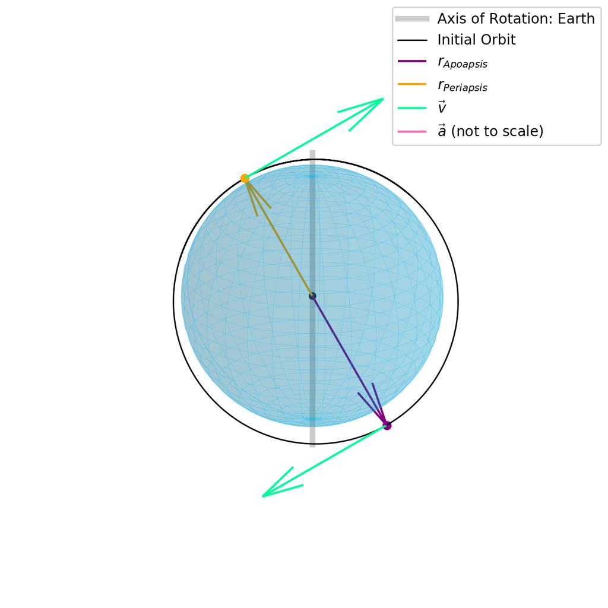

```python
%matplotlib notebook
#fig = plt.figure(dpi=100) #
fig = plt.figure(figsize=(6,6),dpi=135)
#fig = plt.figure(dpi=100)
#ax = fig.add_subplot(111, projection = '3d')
ax = Axes3D(fig)
ax.set_xlim([-8000,8000])
ax.set_ylim([-8000,8000])
ax.set_zlim([-8000,8000])

###########################################
#Add Earth (Bottom Half)
ue1, ve1 = np.mgrid[0:2*np.pi:60j, 0:np.pi:60j]
xe=re*np.cos(ue1)*np.sin(ve1)
ye=re*np.sin(ue1)*np.sin(ve1)
ze=re*np.cos(ve1)
clip0 = int(xe.size / 10)
ax.plot_surface(xe, ye, ze, lw=0.1,alpha=0.2,color='deepskyblue',zorder = -10)
ax.plot_wireframe(xe, ye, ze, lw=0.1,alpha=0.99,color='deepskyblue',zorder = -10)

#Show  Earth Axis of rotation.
ax.plot([0,0],[0,0],[-re*1.2,re*1.2],color='k',lw=4,ls='-',alpha=0.2,label='Axis of Rotation: Earth')
ax.scatter(0,0,0,color='k',alpha=0.8)

###########################################
#Plot First Full Orbit
clip1 = 0
clip2 = 7500
ax.plot(r1[clip1:clip2,0], r1[clip1:clip2,1], r1[clip1:clip2,2],'k',lw=1,zorder = 2.5,label='Initial Orbit')

###########################################
#apoapsis
c_v = 'mediumspringgreen'
c_a = 'hotpink'

i=0
j1 = r1_apo[0][i]
ax.scatter(r1[j1,0],r1[j1,1],r1[j1,2], c=c_ra,s=30) #show location of apoapsis
ax.quiver(0,0,0,r1[j1,0],r1[j1,1],r1[j1,2], color=c_ra,label='$r_{Apoapsis}$') # show vector to apoapsis

#Show velocity vector at apoapsis
scale1 = 1000
ax.quiver(r1[j1,0],r1[j1,1],r1[j1,2],v1rel[j1,0]*scale1,v1rel[j1,1]*scale1,v1rel[j1,2]*scale1, color=c_v)

#Show decel vector at apoapsis
scale2 = 1e15
ax.quiver(r1[j1,0],r1[j1,1],r1[j1,2],a1[j1,0]*scale2,a1[j1,1]*scale2,a1[j1,2]*scale2, color=c_a)

###########################################
#perigee
i=0
j1 = r1_peri[0][i]
ax.scatter(r1[j1,0],r1[j1,1],r1[j1,2], c=c_rp,s=30)#show location of perigee
ax.quiver(0,0,0,r1[j1,0],r1[j1,1],r1[j1,2], color=c_rp,label='$r_{Periapsis}$') # show vector to perigee

#Show velocity vector at perigee
ax.quiver(r1[j1,0],r1[j1,1],r1[j1,2],v1rel[j1,0]*scale1,v1rel[j1,1]*scale1,v1rel[j1,2]*scale1, color=c_v,label='$\\vec v$')

#Show deceleration vector at perigee (Scales of deceleration are not equal)
scale3 = 1e15
ax.quiver(r1[j1,0],r1[j1,1],r1[j1,2],a1[j1,0]*scale3,a1[j1,1]*scale3,a1[j1,2]*scale3, color=c_a,label='$ \\vec a$ (not to scale)')

###########################################
#Label
ax.set_xlabel('x (km)')
ax.set_ylabel('y (km)')
ax.set_zlabel('z (km)')

#Set ticks
ax.set_xticks([-5000,0,5000])
ax.set_yticks([-5000,0,5000])
ax.set_zticks([-5000,0,5000])


plt.legend()
ax.set_axis_off()

plt.show()

animate_rotate = False
if animate_rotate==True:
    for angle in range(0, 360):
        ax.view_init(0, angle)
        fig.canvas.draw()
        plt.pause(.001)

ax.view_init(-22,70)
```

# DO AGAIN BUT ANIMATE THE TRAJECTORY

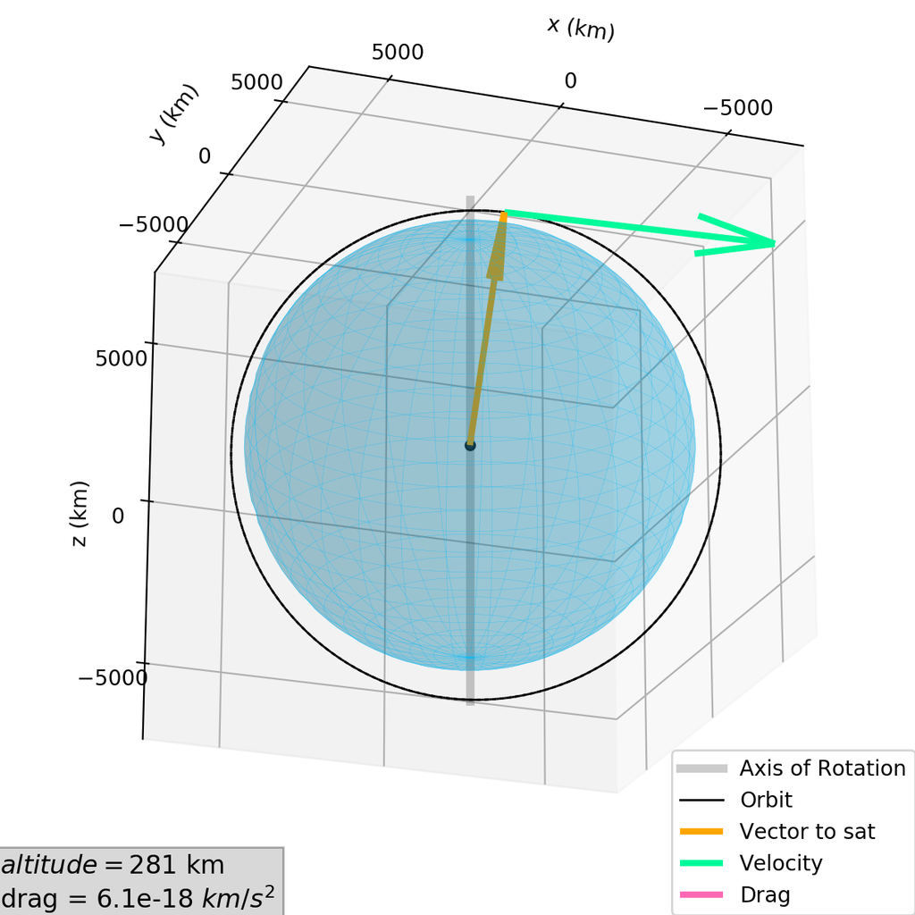

```python
%matplotlib notebook
#fig = plt.figure(dpi=100) #
#fig = plt.figure(dpi=100)


#Very good
fig = plt.figure(figsize=(6,6),dpi=135)



#ax = fig.add_subplot(111, projection = '3d')
ax = Axes3D(fig)
axlim = 7000
ax.set_xlim([-axlim,axlim])
ax.set_ylim([-axlim,axlim])
ax.set_zlim([-axlim,axlim])
ax.view_init(-22,70)

###########################################
#Add Earth (Bottom Half)
ue1, ve1 = np.mgrid[0:2*np.pi:60j, 0:np.pi:60j]
xe=re*np.cos(ue1)*np.sin(ve1)
ye=re*np.sin(ue1)*np.sin(ve1)
ze=re*np.cos(ve1)
clip0 = int(xe.size / 10)
ax.plot_surface(xe, ye, ze, lw=0.1,alpha=0.2,color='deepskyblue',zorder = -10)
ax.plot_wireframe(xe, ye, ze, lw=0.1,alpha=0.99,color='deepskyblue',zorder = -10)

#Show  Earth Axis of rotation.
ax.plot([0,0],[0,0],[-re*1.2,re*1.2],color='k',lw=4,ls='-',alpha=0.2,label='Axis of Rotation')
ax.scatter(0,0,0,color='k',alpha=0.8)

###########################################
#Plot First Full Orbit
#clip1 = 0
#clip2 = 7500
#

###########################################
#apoapsis
c_v = 'mediumspringgreen'
c_a = 'hotpink'


#Label
ax.set_xlabel('x (km)')
ax.set_ylabel('y (km)')
ax.set_zlabel('z (km)')

#Set ticks
ax.set_xticks([-5000,0,5000])
ax.set_yticks([-5000,0,5000])
ax.set_zticks([-5000,0,5000])


#ax.set_axis_off()
def clear_lines():
    quiv_accel.remove()
    quiv_vel.remove()
    quiv_radius.remove()


plt.show()

LW_vec = 3


#For parameter output in plot
line = -20000
ypos_0 = 0.7 #-0.1
xpos_0 =0.02


animation_range = 1000
for j in range(animation_range):


    i = j * 30   # * 80 for display

    #ORBIT
    ax.plot((r1[i,0],r1[i+1,0]), (r1[i,1],r1[i+1,1]), (r1[i,2],r1[i+1,2]),'k',lw=1,color='k',zorder = 2.5,label='Orbit')

    #RADIUS VECTOR
    quiv_radius = ax.quiver(0,0,0,r1[i,0],r1[i,1],r1[i,2], color=c_rp,linewidths=LW_vec, label='Vector to sat')

    #VELOCITY VECTOR
    s1 = 1000
    quiv_vel = ax.quiver(r1[i,0],r1[i,1],r1[i,2],v1rel[i,0]*s1,v1rel[i,1]*s1,v1rel[i,2]*s1,color=c_v,linewidths=LW_vec,label='Velocity')

    #DECEL VECTOR
    s2 = 1e14
    quiv_accel = ax.quiver(r1[i,0],r1[i,1],r1[i,2],a1[i,0]*s2,a1[i,1]*s2,a1[i,2]*s2, color=c_a, linewidths=LW_vec,label = 'Drag')



    text_below = '$altitude =$'+'{0:.0f} km \ndrag = {1:.1e} $km/s^2$'.format(r1_mag[i] - re,a1_mag[i]  )
    text_parameter_1 = ax.text(xpos_0, ypos_0 + 0*line ,0,text_below,
        horizontalalignment='left',
        verticalalignment='bottom',
        size='large',
        bbox=dict(facecolor='gray', alpha=0.3),
        transform = ax.transAxes)




    #SHOW
    fig.canvas.draw()
    plt.pause(0.0001)

    if j == 0:
        plt.legend(loc='lower right',  borderaxespad=0.) #bbox_to_anchor=(1.05, 1),

    #Save frames for video
    export_animation = False
    if export_animation == True:
        frame_name = 'animation/frame_{}'.format(j)
        plt.savefig(frame_name)

    #REMOVE PREVIOUS
    if j < animation_range-1:
        quiv_accel.remove()
        quiv_vel.remove()
        quiv_radius.remove()
        text_parameter_1.remove()

        del quiv_accel
        del quiv_vel
        del quiv_radius
        del text_parameter_1

    #quiv_vel.set_alpha(0)
    #quiv_radius.set_alpha(0)
    #quiv_accel.set_alpha(0)
###########################################

plt.show()
```